# Home_Prices_Random_Forest

### Predicting Sale Price of Homes in King County, WA

### Random Forest Model

#### Team Members

#### Alexandre Makhmudyantsev

#### Brandon Nguyen

#### Ryan Martin Elli Cervantes

#### Triet Lieu

Table of Contents

#### Load Libraries & DataSet

#### Check For Missing Data

#### Plot Price & Grade

#### Split Into Training & Test Subsets

#### Train Random Forests

#### Test & Measure Model

#### Results & Analysis

Introduction

The dataset represents **21613 homes sold in King County**, WA state from the year of May 2014 to May 2015  
19 columns (+ price response variable) hold the value of each home's features,  
but several will not be used in the random forest model...

- **date**: Outside of the scope of this study. Is factor of environment and not home
- **sqft_living**: Sum of sqft_above and sqft_basement, so those 2 already contain sqft_living
- **floors**: Number of floors is already contained in sqft_living
- **yr_renovated**: Most entries will have zero value because those homes are not renovated
- **lat[titude], long[itude], zipcode, date**: Miniscule variation in these features in this localed dataset

King County, WA contains the city of Seattle and is majority suburb, so median incomes  
and home prices border those of the median in America

Load Libraries & DataSet

```python
import pandas as pd
from pandas.plotting import scatter_matrix
import numpy as np  # arrays and math functions
from scipy.stats import uniform  # for training-and-test split
from sklearn.model_selection import train_test_split
from sklearn.tree import DecisionTreeRegressor  # machine learning tree
from sklearn.ensemble import RandomForestRegressor # ensemble method
pd.set_option('display.float_format', lambda x: '%.3f' % x)

homes = pd.read_csv("kc_house_data.csv")
```

```python
print(f"All {len(homes.columns)} columns in kc_house_data.csv")
homes.columns
```

```
All 21 columns in kc_house_data.csv
```

```
Index(['id', 'date', 'price', 'bedrooms', 'bathrooms', 'sqft_living',
       'sqft_lot', 'floors', 'waterfront', 'view', 'condition', 'grade',
       'sqft_above', 'sqft_basement', 'yr_built', 'yr_renovated', 'zipcode',
       'lat', 'long', 'sqft_living15', 'sqft_lot15'],
      dtype='object')
```

```python
del homes["sqft_living"]
del homes["floors"]
del homes["yr_renovated"]
del homes["lat"]
del homes["long"]
del homes["zipcode"]

homes.columns[1:] # Exclude id
```

```
Index(['date', 'price', 'bedrooms', 'bathrooms', 'sqft_lot', 'waterfront',
       'view', 'condition', 'grade', 'sqft_above', 'sqft_basement', 'yr_built',
       'sqft_living15', 'sqft_lot15'],
      dtype='object')
```

Check For Missing Data

```python
counts = homes.isnull().sum()
missing = pd.concat([counts], axis=1, keys=['counts'])
print(missing[1:])
print("\nThere is ", end="")
print("" if missing['counts'].sum() else "no", end="")
print(" missing data", end="")
```

```
               counts
date                0
price               0
bedrooms            0
bathrooms           0
sqft_lot            0
waterfront          0
view                0
condition           0
grade               0
sqft_above          0
sqft_basement       0
yr_built            0
sqft_living15       0
sqft_lot15          0

There is no missing data
```

Plot Price & Grade

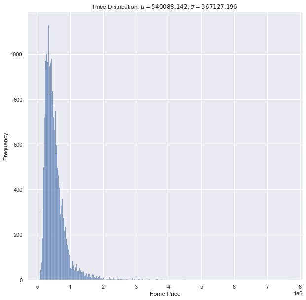

```python
import seaborn as sns
import matplotlib.pyplot as plt

sns.set(rc={'figure.figsize':(10, 10)})

mu = homes['price'].mean()
sigma = homes['price'].std()
plt.xlabel('Home Price')
plt.ylabel('Frequency')

plt.title(r'Price Distribution: $\mu= %.3f,\sigma=%.3f$'%(mu, sigma))
sns.histplot(data = homes, x = 'price');
```

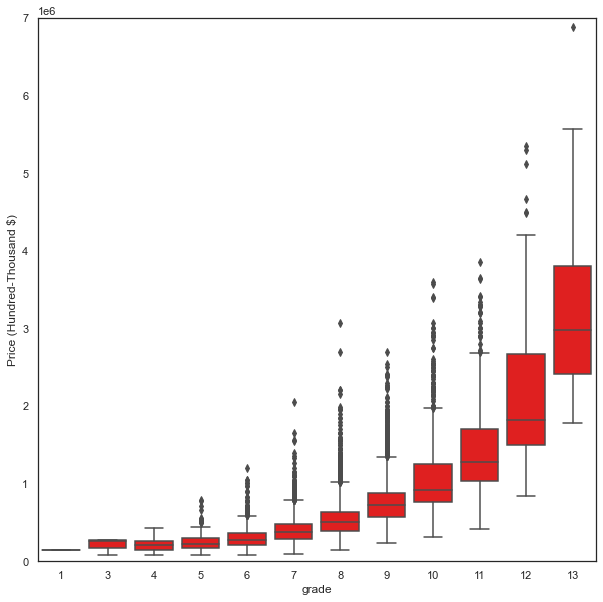

```python
sns.set(style="white")
fig = sns.boxplot(x='grade', y="price", data=homes, color="red")
fig.axis(ymin=0, ymax=7e6);
fig.set_ylabel("Price (Hundred-Thousand $)")
```

As expected, price increases as grade/construction quality increases  
But also note, as grade increases, variance in prices for each grade widens

Split Into Training & Test Subsets

Use a 3:1 train:test ratio on the Random Forest Algorithm

```python
homes_train, homes_test = train_test_split(homes, test_size = 0.25)
print(f"There are {len(homes_train)} entires in the train set")
print(f"There are  {len(homes_test)} entires in the test  set")
```

```
There are 16209 entires in the train set
There are  5404 entires in the test  set
```

Train Random Forests

```python
tree_model = RandomForestRegressor(random_state = 9999)

Y_train = homes_train.loc[:, ['price']]
```

```python
# Unused features: floors, yr_renovated, sqft_living15, sqft_lot15

X_train = homes_train.loc[:, ['bedrooms', 'bathrooms', 'sqft_lot', 'waterfront', 'view', 'condition', 'grade', 'sqft_above', 'sqft_basement', 'yr_built']]
X_test  = homes_test .loc[:, ['bedrooms', 'bathrooms', 'sqft_lot', 'waterfront', 'view', 'condition', 'grade', 'sqft_above', 'sqft_basement', 'yr_built']]

tree_model = tree_model.fit(X_train, Y_train.values.ravel())
```

```python
X_train['pred_price'] = tree_model.predict(X_train)

train_result = round(np.power(homes_train['price'].corr(X_train['pred_price']), 2), 4)

print('Train: Random Forest r^2 Accounted: ', train_result)
```

```
Train: Random Forest r^2 Accounted:  0.9645
```

Test & Measure Model

```python
X_test['pred_price'] = tree_model.predict(X_test)

test_result = round(np.power(homes_test['price'].corr(X_test['pred_price']), 2), 4)

print('Test : Random Forest r^2 Accounted: ', test_result)
```

```
Test : Random Forest r^2 Accounted:  0.6886
```

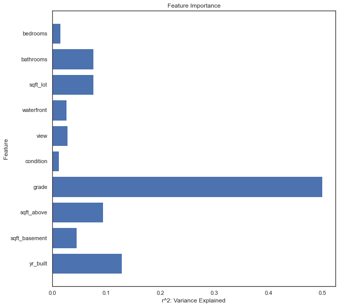

```python
plt.barh(X_train.columns[-2::-1], tree_model.feature_importances_[::-1])

plt.ylabel("Feature")
plt.xlabel("r^2: Variance Explained")
plt.title("Feature Importance")
```

Results & Analysis

```python
print("Feature: Largest to Smallest Variance\n")
zipped = sorted(zip(X_train.columns, tree_model.feature_importances_), key=lambda x: x[1], reverse = True)
for (feature, variance) in zipped:
    print(f'{feature.ljust(15)}: {variance}')
```

```
Feature: Largest to Smallest Variance

grade          : 0.4993842037626034
yr_built       : 0.12865768179109868
sqft_above     : 0.09378712741560893
bathrooms      : 0.0760740850950293
sqft_lot       : 0.07569804406558159
sqft_basement  : 0.045456690576796605
view           : 0.02796624260571406
waterfront     : 0.026660820758766978
bedrooms       : 0.01450767615435036
condition      : 0.011807427774450034
```

**Grade** explains a magnitude more variance than **condition**. We can conclude that buyers value the original build  
grade more than the home's present condition. Perhaps they reason a degraded home can be restored to its original condition,  
but a home built with poor materials from the start cannot be improved.

**Bathrooms** add more to the price than **bedrooms**. It may be because a home typically has more bedrooms than bathrooms,  
so a premium is placed on having more bathrooms than usual